# PML - Course Project

Steven Sheridan

April 27, 2019

# Introduction

Using devices such as Jawbone Up, Nike FuelBand, and Fitbit it is now possible to collect a large amount of data about personal activity relatively inexpensively. These type of devices are part of the quantified self movement - a group of enthusiasts who take measurements about themselves regularly to improve their health, to find patterns in their behavior, or because they are tech geeks. One thing that people regularly do is quantify how much of a particular activity they do, but they rarely quantify how well they do it.

In this project, your goal will be to use data from accelerometers on the belt, forearm, arm, and dumbell of 6 participants. They were asked to perform barbell lifts correctly and incorrectly in 5 different ways. More information is available from the website here: http://groupware.les.inf.puc-rio.br/har (see the section on the Weight Lifting Exercise Dataset).

# Prepare data

Load libraries

Load training and test data

```r
Train<-read.csv(url("https://d396qusza40orc.cloudfront.net/predmachlearn/pml-training.csv"),header=TRUE)
dim(Train)
```

```
## [1] 19622   160
```

```r
Test<-read.csv(url("https://d396qusza40orc.cloudfront.net/predmachlearn/pml-testing.csv"),header=TRUE)
dim(Test)
```

```
## [1]  20 160
```

```r
str(Test)
```

```
## 'data.frame':    20 obs. of  160 variables:
##  $ X                       : int  1 2 3 4 5 6 7 8 9 10 ...
##  $ user_name               : Factor w/ 6 levels "adelmo","carlitos",..: 6 5 5 1 4 5 5 5 2 3 ...
##  $ raw_timestamp_part_1    : int  1323095002 1322673067 1322673075 1322832789 1322489635 1322673149 1322673128 1322673076 1323084240 1322837822 ...
##  $ raw_timestamp_part_2    : int  868349 778725 342967 560311 814776 510661 766645 54671 916313 384285 ...
##  $ cvtd_timestamp          : Factor w/ 11 levels "02/12/2011 13:33",..: 5 10 10 1 6 11 11 10 3 2 ...
##  $ new_window              : Factor w/ 1 level "no": 1 1 1 1 1 1 1 1 1 1 ...
##  $ num_window              : int  74 431 439 194 235 504 485 440 323 664 ...
##  $ roll_belt               : num  123 1.02 0.87 125 1.35 -5.92 1.2 0.43 0.93 114 ...
##  $ pitch_belt              : num  27 4.87 1.82 -41.6 3.33 1.59 4.44 4.15 6.72 22.4 ...
##  $ yaw_belt                : num  -4.75 -88.9 -88.5 162 -88.6 -87.7 -87.3 -88.5 -93.7 -13.1 ...
##  $ total_accel_belt        : int  20 4 5 17 3 4 4 4 4 18 ...
##  $ kurtosis_roll_belt      : logi  NA NA NA NA NA NA ...
##  $ kurtosis_picth_belt     : logi  NA NA NA NA NA NA ...
##  $ kurtosis_yaw_belt       : logi  NA NA NA NA NA NA ...
```

[output cut: 86 more lines]

Remove columns with many missing values

```r
Remove <- which(colSums(is.na(Train) |Train=="")>0.9*dim(Train)[1])
TrainClean<-Train[,-Remove]
TrainClean<-TrainClean[,-c(1:7)]
TestClean<-Test[,-Remove]
TestClean<-TestClean[,-1]
dim(TrainClean)
```

```
## [1] 19622    53
```

```r
dim(TestClean)
```

```
## [1] 20 59
```

After cleaning, the training set has 53 variables.

Partition the data

```r
set.seed(2319)
DP <- createDataPartition(TrainClean$classe, p=0.75, list=FALSE)
TrainP <- TrainClean[DP,]
TestP <- TrainClean[-DP,]
dim(TrainP)
```

```
## [1] 14718    53
```

```r
dim(TestP)
```

```
## [1] 4904   53
```

Three different methods for prediction are tested below. The cross-validation technique is being applied and five folds are being used.

# Classification Tree

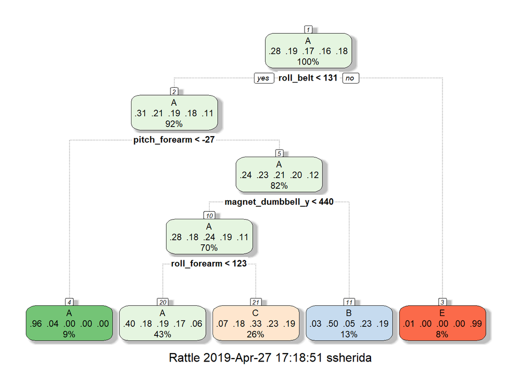

```r
trControl <- trainControl(method="cv", number=5)
model_CT <- train(classe~., data=TrainP, method="rpart", trControl=trControl)
fancyRpartPlot(model_CT$finalModel)
```

```r
predCT <- predict(model_CT,newdata=TestP)
CMCT <- confusionMatrix(TestP$classe,predCT)
CMCT$table
```

```
##           Reference
## Prediction    A    B    C    D    E
##          A 1266   28   97    0    4
##          B  414  322  213    0    0
##          C  393   23  439    0    0
##          D  364  133  307    0    0
##          E  138  125  243    0  395
```

```r
CMCT$overall[1]
```

```
##  Accuracy
## 0.4938825
```

This model has very low accuracy of just about 50%.

# Gradient Boosting Method

```r
model_GBM <- train(classe~., data=TrainP, method="gbm", trControl=trControl, verbose=FALSE)
print(model_GBM)
```

```
## Stochastic Gradient Boosting
##
## 14718 samples
##    52 predictor
##     5 classes: 'A', 'B', 'C', 'D', 'E'
##
## No pre-processing
## Resampling: Cross-Validated (5 fold)
## Summary of sample sizes: 11776, 11775, 11774, 11774, 11773
## Resampling results across tuning parameters:
##
##   interaction.depth  n.trees  Accuracy   Kappa
##   1                   50      0.7524117  0.6861269
##   1                  100      0.8200157  0.7721644
##   1                  150      0.8527654  0.8136323
##   2                   50      0.8552119  0.8165488
##   2                  100      0.9052184  0.8800679
##   2                  150      0.9292031  0.9104162
##   3                   50      0.8974047  0.8701083
##   3                  100      0.9415008  0.9259851
##   3                  150      0.9615437  0.9513537
##
## Tuning parameter 'shrinkage' was held constant at a value of 0.1
##
## Tuning parameter 'n.minobsinnode' was held constant at a value of 10
## Accuracy was used to select the optimal model using the largest value.
## The final values used for the model were n.trees = 150,
##  interaction.depth = 3, shrinkage = 0.1 and n.minobsinnode = 10.
```

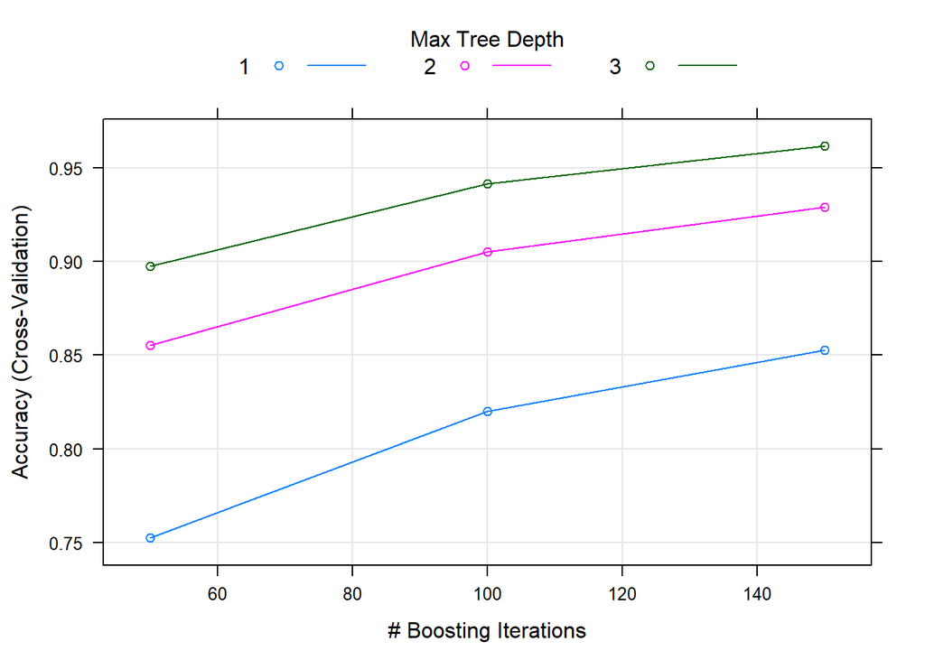

```r
plot(model_GBM)
```

```r
predGBM<-predict(model_GBM,newdata=TestP)
CMGBM<-confusionMatrix(TestP$classe,predGBM)
CMGBM$table
```

```
##           Reference
## Prediction    A    B    C    D    E
##          A 1371   14    7    3    0
##          B   26  894   28    1    0
##          C    0   27  818   10    0
##          D    0    2   20  776    6
##          E    2   14    8   11  866
```

```r
CMGBM$overall[1]
```

```
##  Accuracy
## 0.9634992
```

This model peformed much better than the classification tree, but there is still some room for improvement.

# Random Forests Method

```r
model_RF<-train(classe~., data=TrainP, method="rf", trControl=trControl, verbose=FALSE)
print(model_RF)
```

```
## Random Forest
##
## 14718 samples
##    52 predictor
##     5 classes: 'A', 'B', 'C', 'D', 'E'
##
## No pre-processing
## Resampling: Cross-Validated (5 fold)
## Summary of sample sizes: 11773, 11775, 11775, 11776, 11773
## Resampling results across tuning parameters:
##
##   mtry  Accuracy   Kappa
##    2    0.9921863  0.9901150
##   27    0.9927976  0.9908884
##   52    0.9880419  0.9848723
##
## Accuracy was used to select the optimal model using the largest value.
## The final value used for the model was mtry = 27.
```

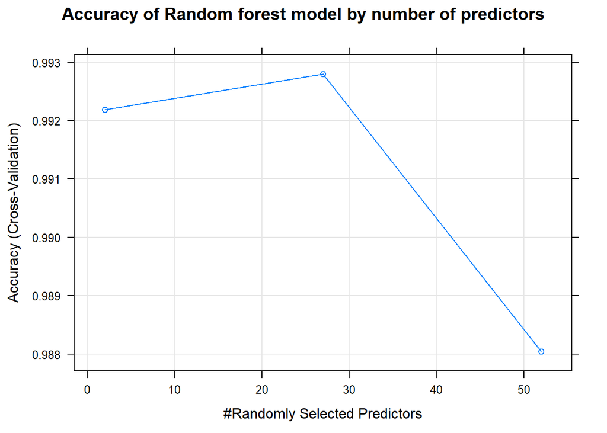

```r
plot(model_RF,main="Accuracy of Random forest model by number of predictors")
```

```r
predRF<-predict(model_RF,newdata=TestP)
CMRF<-confusionMatrix(TestP$classe,predRF)
CMRF$table
```

```
##           Reference
## Prediction    A    B    C    D    E
##          A 1393    2    0    0    0
##          B    4  939    6    0    0
##          C    0    1  853    1    0
##          D    0    0    2  801    1
##          E    0    1    1    2  897
```

```r
CMRF$overall[1]
```

```
##  Accuracy
## 0.9957178
```

# Summary